# EDA

## Base Plotting system.

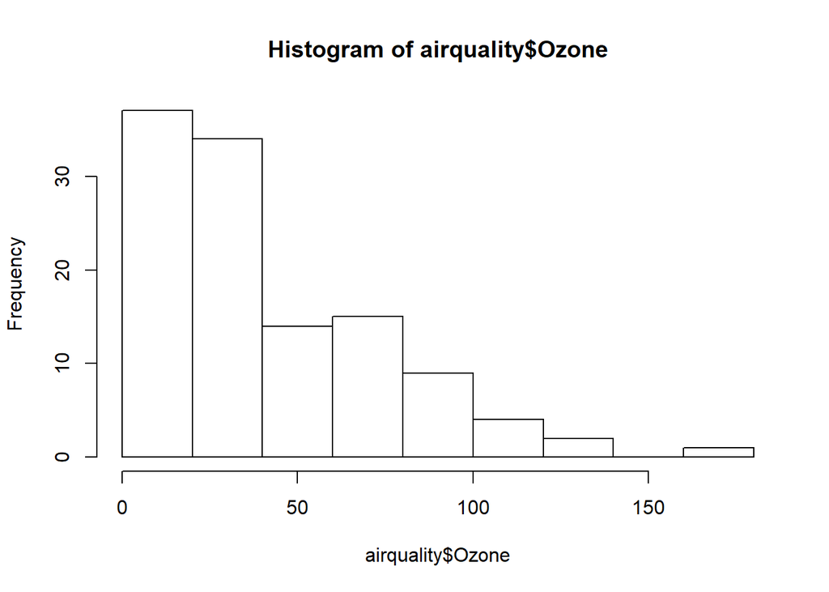

```r
library(datasets)
hist(airquality$Ozone)
```

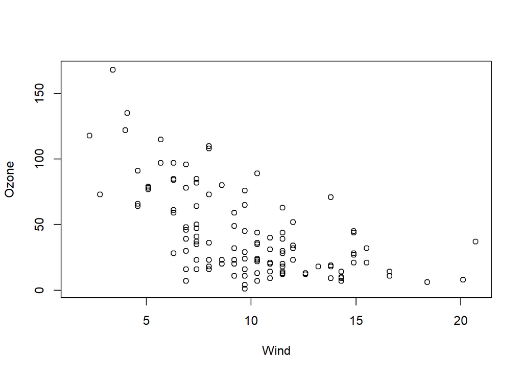

```r
with(airquality, plot(Wind,Ozone))
```

```r
library(datasets)
str(airquality)
```

```
## 'data.frame':    153 obs. of  6 variables:
##  $ Ozone  : int  41 36 12 18 NA 28 23 19 8 NA ...
##  $ Solar.R: int  190 118 149 313 NA NA 299 99 19 194 ...
##  $ Wind   : num  7.4 8 12.6 11.5 14.3 14.9 8.6 13.8 20.1 8.6 ...
##  $ Temp   : int  67 72 74 62 56 66 65 59 61 69 ...
##  $ Month  : int  5 5 5 5 5 5 5 5 5 5 ...
##  $ Day    : int  1 2 3 4 5 6 7 8 9 10 ...
```

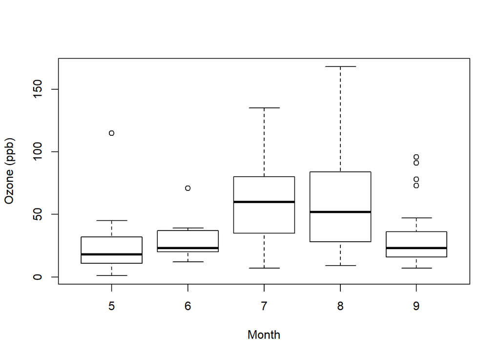

```r
boxplot(Ozone ~ Month, airquality, xlab = "Month", ylab = "Ozone (ppb)")
```

Some important base graphics parameters:

- `pch` is the plotting symbol, being the open circle the default.
- `lty` is for line type, being the default the solid line.
- `lwd` is the line width.
- `col` is for the color, specified by a number, string or hex code; the function `colors` display a list of colors by name.
- `xlab` and `ylab` are the $x$ and $y$ axis label.
- `las` the orientation of the axis labels.
- `bg` background color.
- `mar` the margin size.
- `oma` is the outer margin size.
- `mfrow` is the number of plots by row, whereas `mfcol` is the same for columns. Plots are filled row-wise or column-wise when `mfrow` and `mfcol` are used, respectively.

Default values:

```r
par(c("bg", "col", "mar", "mfrow"))
```

```
## $bg
## [1] "white"
##
## $col
## [1] "black"
##
## $mar
## [1] 5.1 4.1 4.1 2.1
##
## $mfrow
## [1] 1 1
```

```r
# mar is clockwise starting at bottom: bottom, left, top, right.
```